# RNA seq analysis

Install (if required) and load required bioconductor packages

```r
# Install BiocManager, if required
if (!require("BiocManager", quietly = TRUE))
  install.packages("BiocManager")
BiocManager::install(version = "3.19")
```

```r
packages <- c("DESeq2",
              "pheatmap",
              "RColorBrewer",
              "tidyverse",
              "apeglm")
new.packages <- packages[!(packages %in% installed.packages()[,"Package"])]

# Install bioconductor packages, if not installed
if(length(new.packages))
  BiocManager::install(new.packages)

# Load all bioconductor packages
invisible(lapply(packages, library, character.only=TRUE))
```

```
## ✖ lubridate::%within%() masks IRanges::%within%()
## ✖ lubridate::second<-() masks S4Vectors::second<-()
```

Set working directory and create an output folder

```r
# Set working directory
if (!require("rstudioapi")) {
  install.packages("rstudioapi")
  library(rstudioapi)
}
# Set the directory with current script as working directory
setwd(dirname(rstudioapi::getActiveDocumentContext()$path))

# Create output folder
ifelse(!dir.exists(file.path("./Output")),
  dir.create(file.path("./Output")),
  "Directory Exists"
)
```

```
## [1] "Directory Exists"
```

```r
list.files()
```

```
## [1] "DESeq2_smoc2.R"     "DESeq2_smoc2.Rmd"   "DESeq2_smoc2_files"
## [4] "Input"              "Output"             "readme.md"
```

Load the data file

```r
# Read the table
rawcount <- read.table("./Input/rawcounts.csv",
  sep = ",",
  header = TRUE,
  row.names = 1
)

head(rawcount) # Check column names
```

|  | smoc2_fibrosis1 | smoc2_fibrosis4 | smoc2_normal1 | smoc2_normal3 | smoc2_fibrosis3 | smoc2_normal4 | smoc2_fibrosis2 |
| --- | --- | --- | --- | --- | --- | --- | --- |
| ENSMUSG00000102693 | 0 | 0 | 0 | 0 | 0 | 0 | 0 |
| ENSMUSG00000064842 | 0 | 0 | 0 | 0 | 0 | 0 | 0 |
| ENSMUSG00000051951 | 72 | 30 | 0 | 3 | 36 | 1 | 51 |
| ENSMUSG00000102851 | 0 | 0 | 0 | 0 | 0 | 0 | 0 |
| ENSMUSG00000103377 | 0 | 0 | 1 | 0 | 0 | 0 | 0 |
| ENSMUSG00000104017 | 0 | 0 | 0 | 0 | 0 | 0 | 0 |

```r
dim(rawcount) # Check row count
```

```
## [1] 47729     7
```

Define and create metadata table

```r
# Define metadata
sample_type <- c(
  "smoc2_oe",
  "smoc2_oe",
  "smoc2_oe",
  "smoc2_oe",
  "smoc2_oe",
  "smoc2_oe",
  "smoc2_oe"
)
condition <- c(
  "fibrosis",
  "fibrosis",
  "fibrosis",
  "fibrosis",
  "normal",
  "normal",
  "normal"
)
row_names <- c(
  "smoc2_fibrosis1",
  "smoc2_fibrosis2",
  "smoc2_fibrosis3",
  "smoc2_fibrosis4",
  "smoc2_normal1",
  "smoc2_normal3",
  "smoc2_normal4"
)
color <- c(
  "salmon1",
  "salmon1",
  "salmon1",
  "salmon1",
  "cadetblue1",
  "cadetblue1",
  "cadetblue1"
)

# Create metadata datadrame
metadata <- data.frame(
  row.names = TRUE,
  row_names,
  sample_type,
  condition,
  color
)

metadata # View the table
```

|  | sample_type | condition | color |
| --- | --- | --- | --- |
| smoc2_fibrosis1 | smoc2_oe | fibrosis | salmon1 |
| smoc2_fibrosis2 | smoc2_oe | fibrosis | salmon1 |
| smoc2_fibrosis3 | smoc2_oe | fibrosis | salmon1 |
| smoc2_fibrosis4 | smoc2_oe | fibrosis | salmon1 |
| smoc2_normal1 | smoc2_oe | normal | cadetblue1 |
| smoc2_normal3 | smoc2_oe | normal | cadetblue1 |
| smoc2_normal4 | smoc2_oe | normal | cadetblue1 |

Reorder the columns of rawcount table to match the row order of metadata

```r
# Check the data order with respect to metadata
all(colnames(rawcount) == rownames(metadata))
```

```
## [1] FALSE
```

```r
# Define a function to reorder data columns to match metadata
fn <- match(
  rownames(metadata),
  colnames(rawcount)
)

# Reorder the data columns
reordered_rawcounts <- rawcount[, fn]

# Confirm the data order (all() function can also be used)
identical(
  colnames(reordered_rawcounts),
  rownames(metadata)
)
```

```
## [1] TRUE
```

Visualize rawcount data

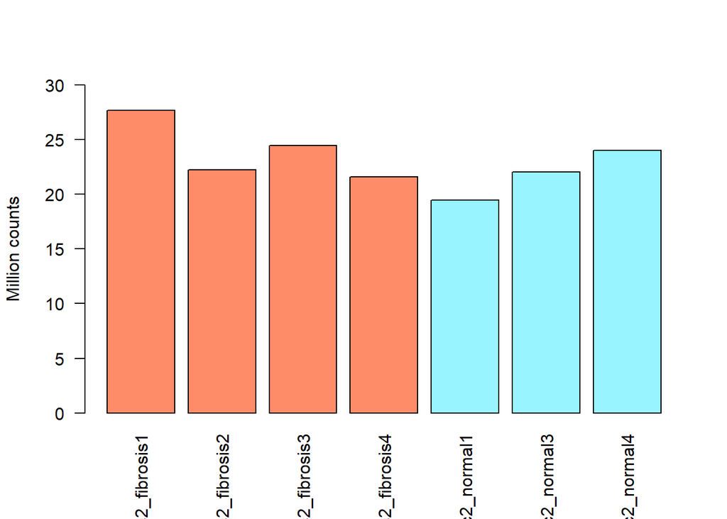

```r
barplot(colSums(reordered_rawcounts) / 1000000,
  col = metadata$color,
  ylab = "Million counts",
  cex.names = 1,
  las = 2,
  ylim = c(0, 30)
)
```

Normalize gene counts

```r
# Create a DESeq2 object
dds <- DESeqDataSetFromMatrix(
  countData = reordered_rawcounts,
  colData = metadata,
  design = ~condition
)
# Determine the size factors
dds <- estimateSizeFactors(dds)

# Extract the normalized counts
normalized_count <- counts(dds,
  normalized = TRUE
)
```

Visualize normalized counts

```
## using ntop=500 top features by variance
```

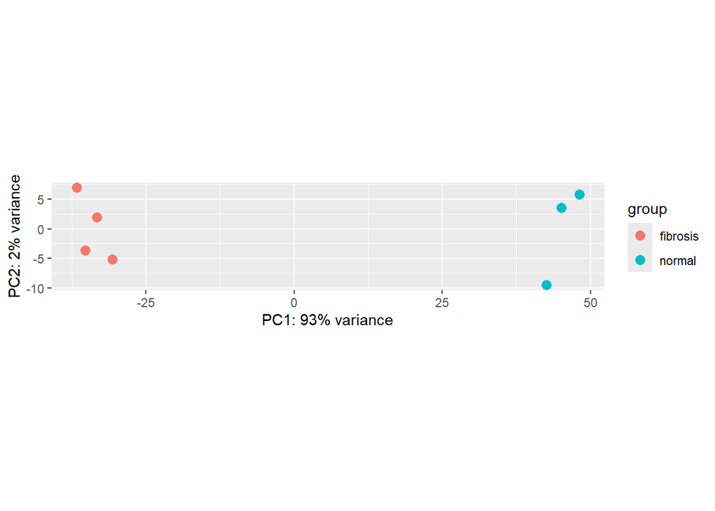

```r
# Log transformation of the the normalized counts
vsd <- vst(dds, blind = TRUE)

# Plot the PCA of PC1 and PC2
plotPCA(vsd,
  intgroup = "condition"
)
```

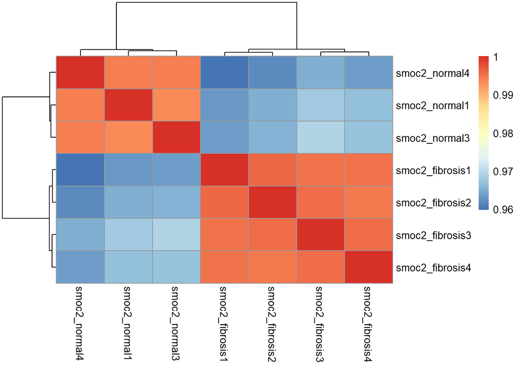

```r
vsd_mat <- assay(vsd) # Extract the transformed counts matrix
vsd_cor <- cor(vsd_mat) # Compute the correlation between samples

# Plot the heatmap for corelation values
pheatmap(vsd_cor)
```

Estimate size factors and dispersion followed by fitting negative binomial model (Wald test)

```r
dds <- DESeq(dds)
```

Check default order of comparison selected, which is indicated by “condition_test_vs_reference”. If the wrong group is set as reference, re-level and run wald test again to change the order.

```r
# Check for comparison order; expectation: condition_fibrosis_vs_normal
resultsNames(dds)
```

```
## [1] "Intercept"                    "condition_normal_vs_fibrosis"
```

```r
# relevel to set normal as reference,
dds$condition <- relevel(dds$condition, ref = "normal")
# re-run waldTest
dds <- nbinomWaldTest(dds)
```

```
## found results columns, replacing these
```

```r
# check comparison order again
resultsNames(dds)
```

```
## [1] "Intercept"                    "condition_fibrosis_vs_normal"
```

Explore the fit of the data to the negative binomial model by plotting the dispersion estimates

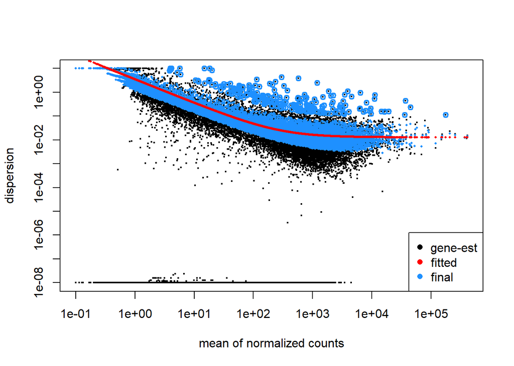

```r
plotDispEsts(dds)
```

Extract the log2 fold changes of the fibrosis group relative to normal Setting a threshold to fold change (not always prefered) will return lesser but biologically relevant DEGs

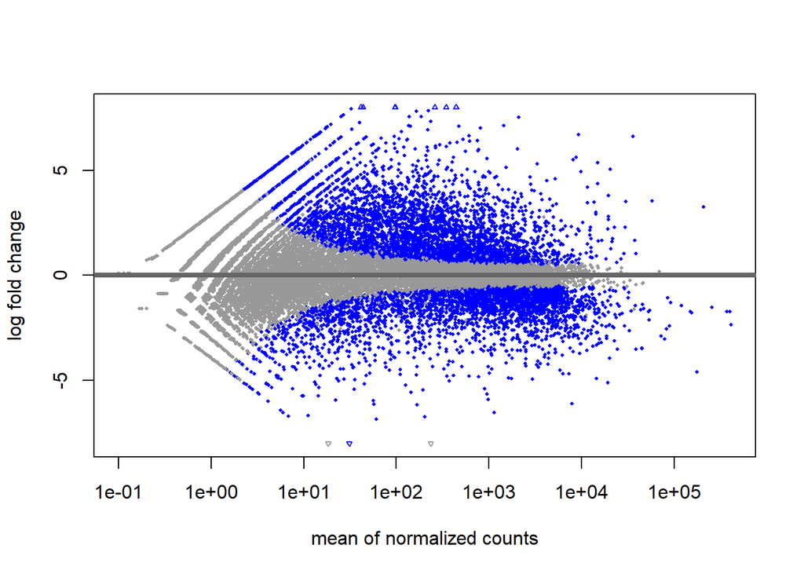

```r
# Extract results
res <- results(dds,
  alpha = 0.05,
  lfcThreshold = 0.32
) # 0.32 lfcThreshold for 1.25 fold change

# MA plot before shrinking
plotMA(res,
  ylim = c(-8, 8)
)
```

Improve the estimated log2 fold change by shrinking the results Note: This might throw a warning if results have transcripts with baseMean=0.

```r
# Shrink the log2 fold changes
res <- lfcShrink(dds,
  type = "apeglm",
  coef = 2,
  res = res
)
```

```
## using 'apeglm' for LFC shrinkage. If used in published research, please cite:
##     Zhu, A., Ibrahim, J.G., Love, M.I. (2018) Heavy-tailed prior distributions for
##     sequence count data: removing the noise and preserving large differences.
##     Bioinformatics. https://doi.org/10.1093/bioinformatics/bty895
```

```
## Warning in nbinomGLM(x = x, Y = YNZ, size = size, weights = weightsNZ, offset =
## offsetNZ, : the line search routine failed, unable to sufficiently decrease the
## function value
```

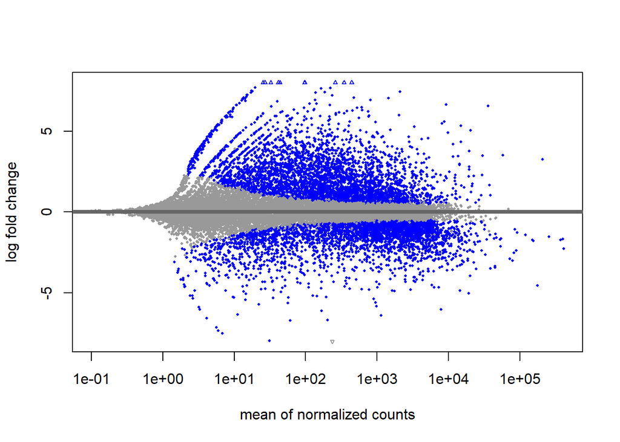

```r
# MA plot after shrinking
plotMA(res,
  ylim = c(-8, 8)
)
```

Extract and save the significant DEGs from the results with padj < 0.05

```r
summary(res) # Overview of the results
```

```
##
## out of 29556 with nonzero total read count
## adjusted p-value < 0.05
## LFC > 0 (up)       : 4011, 14%
## LFC < 0 (down)     : 3552, 12%
## outliers [1]       : 15, 0.051%
## low counts [2]     : 7207, 24%
## (mean count < 1)
## [1] see 'cooksCutoff' argument of ?results
## [2] see 'independentFiltering' argument of ?results
```

```r
# Generate result table
deg <- data.frame(res)
# Create subset of results having only the significant DEGs
deg_sig <- subset(
  deg,
  padj < 0.05
)

# Save results
write.table(deg_sig,
  "Output/smoc2_DEG_sig.txt",
  sep = "\t",
  row.names = TRUE
)
```

Visualize the results:

Volcano plot of significant DEGs, where red and green dots represent down-regulated and up-regulated genes, respectively, with the fold change of greater than 1.

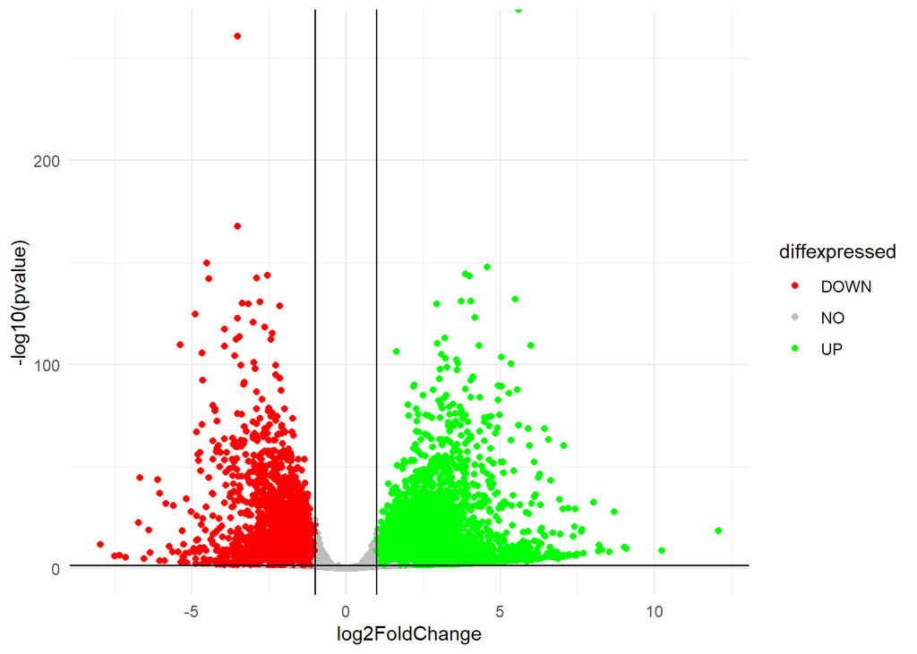

```r
de <- deg[complete.cases(deg), ] # Filter out NA
# Add new column to define differential expression
de$diffexpressed <- "NO"
# Define up-regulated and down-regulated genes
de$diffexpressed[de$log2FoldChange > 1 & de$padj < 0.05] <- "UP"
de$diffexpressed[de$log2FoldChange < -1 & de$padj < 0.05] <- "DOWN"
# Asign colors
mycolors <- c("red", "green", "grey")
names(mycolors) <- c("DOWN", "UP", "NO")

# Volcano plot
ggplot(
  data = de,
  aes(
    x = log2FoldChange,
    y = -log10(pvalue),
    col = diffexpressed
  )
) +
  geom_point() +
  theme_minimal() +
  scale_colour_manual(values = mycolors) +
  geom_vline(
    xintercept = c(-1, 1),
    col = "black"
  ) +
  geom_hline(
    yintercept = -log10(0.05),
    col = "black"
  )
```

Heatmap of normalized counts of significant DEGs

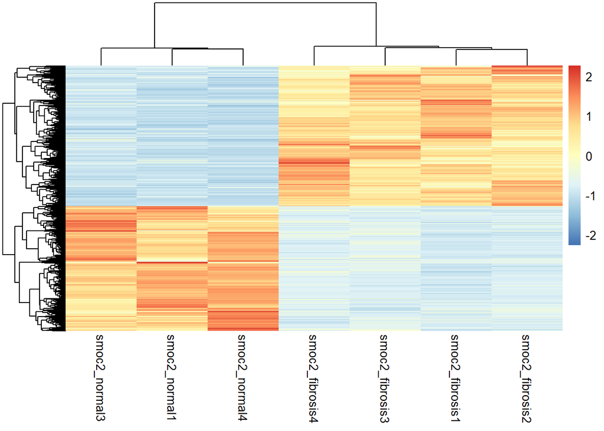

```r
# Generate a table with normalized counts
normalized_count_table <- data.frame(normalized_count)

# Subset the table having only significant DEGs
sig_norm_counts <- normalized_count_table[rownames(deg_sig), ]

# Plot heatmap
pheatmap(sig_norm_counts,
  cluster_rows = TRUE,
  show_rownames = FALSE,
  scale = "row"
)
```